# FDC: Level 4

Ramon Massoni-Badosa

2021/08/18

NOTE: from level 4/5 onwards I will execute most steps locally, as the datasets are not as large anymore.

# 1 Introduction

Here, we will include the annotation of the FDC cells (level 4).

## 1.1 Load packages

```r
library(Seurat)
library(SeuratWrappers)
library(harmony)
library(clusterProfiler)
library(org.Hs.eg.db)
library(tidyverse)
```

## 1.2 Parameters

```r
# Paths
path_to_obj <- "~/Desktop/CNAG/mnt_clust/tonsil_atlas/current/scRNA-seq/results/R_objects/level_3/FDC/FDC_clustered_level_3_with_pre_freeze.rds"
path_to_save_proliferative <- "~/Desktop/CNAG/mnt_clust/tonsil_atlas/current/scRNA-seq/results/R_objects/level_4/FDC/FDC_proliferative_level_4.rds"
path_to_save_epithelial <- "~/Desktop/CNAG/mnt_clust/tonsil_atlas/current/scRNA-seq/results/R_objects/level_4/FDC/epithelial_level_4.rds"
path_to_save_fdc <- "~/Desktop/CNAG/mnt_clust/tonsil_atlas/current/scRNA-seq/results/R_objects/level_4/FDC/FDC_all_level_4.rds"


# Colors
color_palette <-  c("#1CFFCE", "#90AD1C", "#C075A6", "#85660D", "#5A5156", "#AA0DFE",
                    "#F8A19F", "#F7E1A0", "#1C8356", "#FEAF16", "#822E1C", "#C4451C",
                    "#1CBE4F", "#325A9B", "#F6222E", "#FE00FA", "#FBE426", "#16FF32",
                    "black",   "#3283FE", "#B00068", "#DEA0FD", "#B10DA1", "#E4E1E3",
                    "#90AD1C", "#FE00FA", "#85660D", "#3B00FB", "#822E1C", "coral2",
                    "#1CFFCE", "#1CBE4F", "#3283FE", "#FBE426", "#F7E1A0", "#325A9B",
                    "#2ED9FF", "#B5EFB5", "#5A5156", "#DEA0FD", "#FEAF16", "#683B79",
                    "#B10DA1", "#1C7F93", "#F8A19F", "dark orange", "#FEAF16", "#FBE426",
                    "Brown")

# Functions
source("~/Desktop/CNAG/mnt_clust/tonsil_atlas/current/scRNA-seq/bin/utils.R")
```

## 1.3 Load data

```r
seurat <- readRDS(path_to_obj)
seurat
```

```
## An object of class Seurat
## 37378 features across 1508 samples within 1 assay
## Active assay: RNA (37378 features, 3000 variable features)
##  3 dimensional reductions calculated: pca, umap, harmony
```

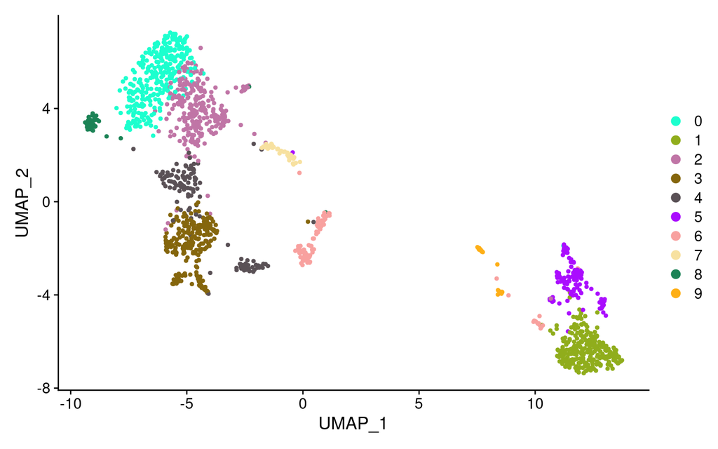

```r
DimPlot(seurat, cols = color_palette)
```

# 2 Explore

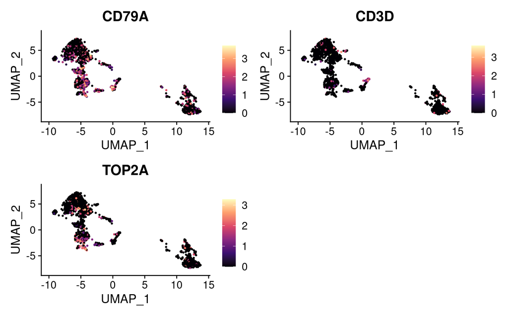

```r
FeaturePlot(seurat, c("CD79A", "CD3D", "TOP2A"), pt.size = 0.5) &
  scale_color_viridis_c(option = "magma")
```

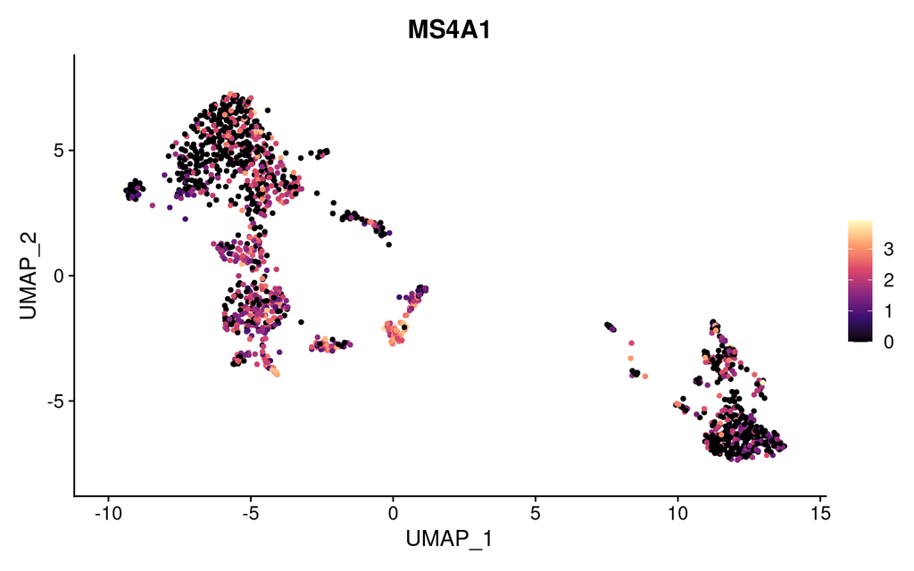

```r
FeaturePlot(seurat, "MS4A1") +
  scale_color_viridis_c(option = "magma")
```

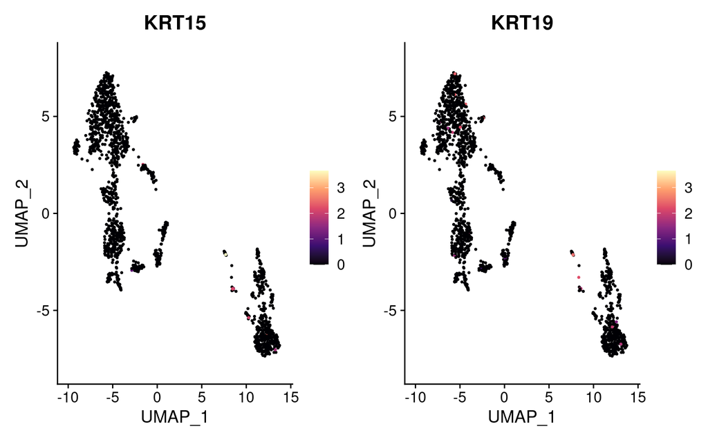

```r
FeaturePlot(seurat, c("KRT15", "KRT19"), pt.size = 0.5) &
  scale_color_viridis_c(option = "magma")
```

# 3 TODO

- Merge clusters 0 and 2. Cluster 2 has a poorly defined signature, and some markers of B cells. We will subcluster it to see if we can separate doublets and FDC.
- Remove cluster 4 (doublets with B cells).
- Remove cluster 6 (doublets: top half doublets with T cells, bottom half doublet with B cell).
- Divide cluster 3 in cycling (left) + doublets (right). Remove doublets
- Subset cluster 9 and merge it with epithelial cells (it expresses KRT19 and KRT15).

Important literature

- [Application of Tonsil-Derived Mesenchymal Stem Cells in Tissue Regeneration: Concise Review](https://stemcellsjournals.onlinelibrary.wiley.com/doi/10.1002/stem.3058)

# 4 Remove

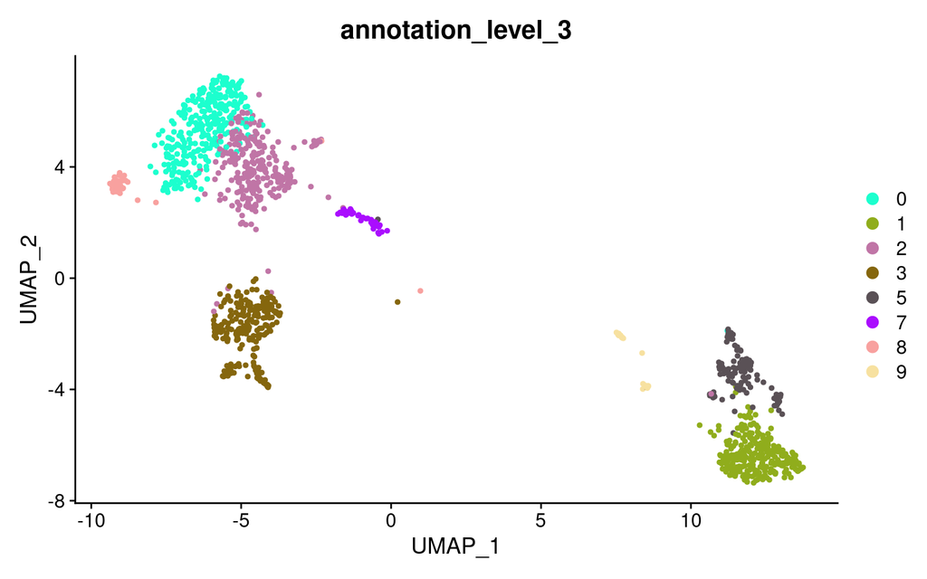

```r
seurat$annotation_level_3 <- as.character(seurat$seurat_clusters)
selected_cells <- colnames(seurat)[!(seurat$annotation_level_3 %in% c("4", "6"))]
seurat <- subset(seurat, cells = selected_cells)
DimPlot(seurat, group.by = "annotation_level_3", cols = color_palette)
```

# 5 Subcluster

### 5.0.1 Cluster 2

```r
Idents(seurat) <- "annotation_level_3"
seurat <- FindNeighbors(seurat, reduction = "harmony", dims = 1:20)
seurat <- FindSubCluster(seurat, "2", "RNA_snn", "sub2", resolution = 0.6)
```

```
## Modularity Optimizer version 1.3.0 by Ludo Waltman and Nees Jan van Eck
##
## Number of nodes: 258
## Number of edges: 10121
##
## Running Louvain algorithm...
## Maximum modularity in 10 random starts: 0.5373
## Number of communities: 3
## Elapsed time: 0 seconds
```

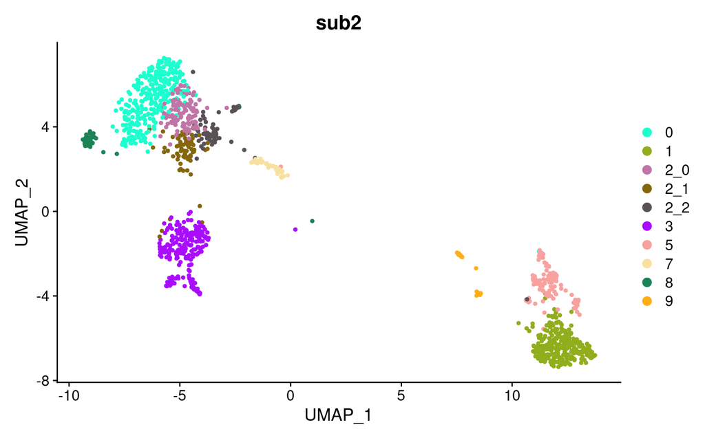

```r
DimPlot(seurat, group.by = "sub2", cols = color_palette)
```

```r
Idents(seurat) <- "sub2"
markers_sub2 <- find_markers_subclusters(seurat, "sub2", "^2_")
DT::datatable(markers_sub2$`2_0`)
```

|  | gene | p_val | avg_log2FC | pct.1 | pct.2 | p_val_adj |
| --- | --- | --- | --- | --- | --- | --- |
| 1 | LAMTOR2 | 0.00541773969617761 | 0.947714993661739 | 0.219 | 0.111 | 1 |
| 2 | CD63 | 4.95767570310017e-06 | 0.819492302568288 | 0.746 | 0.528 | 0.185308002430478 |
| 3 | RAB32 | 0.0156281400191939 | 0.814084962393198 | 0.167 | 0.076 | 1 |
| 4 | SYNE2 | 0.0221508937895303 | 0.76678865143836 | 0.167 | 0.083 | 1 |
| 5 | MT-ND6 | 0.0290518726448651 | 0.766610004110935 | 0.263 | 0.174 | 1 |
| 6 | TECR | 0.0348057943007298 | 0.760666285796712 | 0.175 | 0.097 | 1 |
| 7 | RBPJ | 0.00730856778788047 | 0.730836798035347 | 0.36 | 0.236 | 1 |
| 8 | NME4 | 0.0305486159344201 | 0.716545596340784 | 0.263 | 0.167 | 1 |
| 9 | CRIP2 | 0.00233627638378751 | 0.702600651027947 | 0.377 | 0.236 | 1 |
| 10 | G0S2 | 0.00426431882874645 | 0.698556311267463 | 0.579 | 0.465 | 1 |

[output cut: 45 more lines]

```r
DT::datatable(markers_sub2$`2_1`)
```

|  | gene | p_val | avg_log2FC | pct.1 | pct.2 | p_val_adj |
| --- | --- | --- | --- | --- | --- | --- |
| 1 | ADPRHL2 | 7.37544082155802e-05 | 0.8182044005836 | 0.135 | 0.016 | 1 |
| 2 | ANP32B | 7.8875303677705e-06 | 0.797624574377268 | 0.662 | 0.326 | 0.294820110086526 |
| 3 | DUSP2 | 0.00533739203329477 | 0.74991827689264 | 0.122 | 0.033 | 1 |
| 4 | ZC3H15 | 0.000346986631358964 | 0.735143135843614 | 0.257 | 0.082 | 1 |
| 5 | NAA38 | 0.00221155397116448 | 0.734767047957941 | 0.351 | 0.168 | 1 |
| 6 | SYPL1 | 0.000248708445946382 | 0.731458629497723 | 0.189 | 0.043 | 1 |
| 7 | UQCC2 | 0.00192125659422152 | 0.727003601335527 | 0.203 | 0.071 | 1 |
| 8 | CYCS | 0.0107854527401613 | 0.72335857039212 | 0.203 | 0.087 | 1 |
| 9 | OAT | 0.000310541479438159 | 0.704606115033731 | 0.135 | 0.022 | 1 |
| 10 | RGS13 | 0.0120366724643427 | 0.687952454504179 | 0.284 | 0.147 | 1 |

[output cut: 68 more lines]

```r
DT::datatable(markers_sub2$`2_2`)
```

|  | gene | p_val | avg_log2FC | pct.1 | pct.2 | p_val_adj |
| --- | --- | --- | --- | --- | --- | --- |
| 1 | IGLC3 | 0.374162489185941 | 1.84440020946055 | 0.486 | 0.484 | 1 |
| 2 | MALAT1 | 0.00321278152377538 | 1.65474335450613 | 0.871 | 0.814 | 1 |
| 3 | NEAT1 | 0.0196683076850278 | 1.5158559161311 | 0.186 | 0.09 | 1 |
| 4 | BTG1 | 2.86337129413004e-07 | 1.44781160584963 | 0.514 | 0.202 | 0.0107027092231993 |
| 5 | HSPA1A | 0.671824951644277 | 1.2838728635769 | 0.1 | 0.128 | 1 |
| 6 | TXNIP | 0.00241064591308237 | 1.21884006289939 | 0.271 | 0.122 | 1 |
| 7 | HLA-DPB1 | 0.000678742810070561 | 1.07004409454492 | 0.657 | 0.468 | 1 |
| 8 | XIST | 0.00909789958017252 | 1.05843178493486 | 0.143 | 0.048 | 1 |
| 9 | HLA-DRB1 | 8.48839309163122e-05 | 1.03946508591542 | 0.486 | 0.282 | 1 |
| 10 | PPP1R12A | 3.70515073597668e-05 | 1.03454454564662 | 0.257 | 0.069 | 1 |

[output cut: 196 more lines]

Clearly, cluster 2_2 expressed B cell markers, so we will remove it:

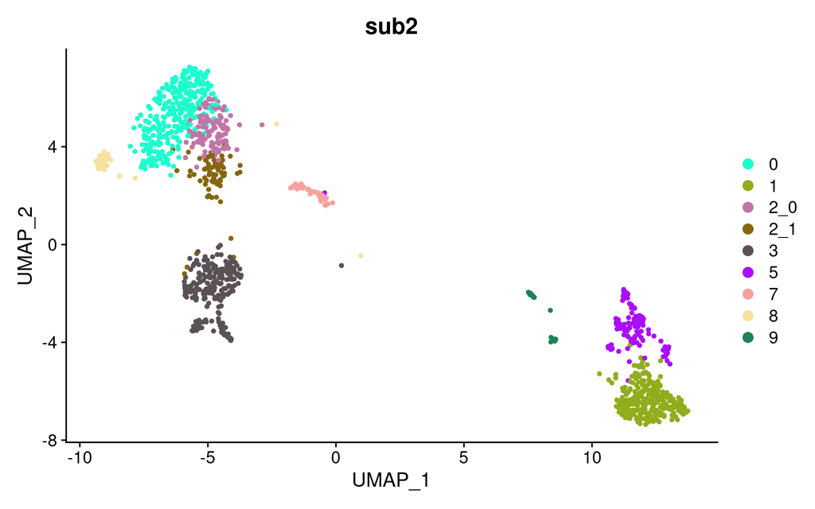

```r
seurat <- subset(seurat, sub2 != "2_2")
DimPlot(seurat, group.by = "sub2", cols = color_palette)
```

```r
markers_2vs0 <- FindMarkers(seurat, ident.1 = c("2_0", "2_1"), ident.2 = "0", only.pos = TRUE)
DT::datatable(markers_2vs0)
```

|  | p_val | avg_log2FC | pct.1 | pct.2 | p_val_adj |
| --- | --- | --- | --- | --- | --- |
| RPS2 | 1.49708706488957e-18 | 0.621747082335961 | 1 | 0.987 | 5.59581203114424e-14 |
| RPL28 | 4.2074153163146e-18 | 0.600616316793896 | 1 | 0.99 | 1.57264769693207e-13 |
| RPS23 | 4.8979285739441e-15 | 0.575125765293624 | 1 | 0.964 | 1.83074774236883e-10 |
| RPS8 | 1.0770094922575e-14 | 0.55953223112287 | 0.995 | 0.993 | 4.02564608016008e-10 |
| RPS24 | 2.6508048341622e-14 | 0.521052282111814 | 0.984 | 0.971 | 9.90817830913147e-10 |
| RPS12 | 3.49362902536649e-14 | 0.599928815745999 | 1 | 0.974 | 1.30584865710149e-09 |
| RPS29 | 3.72395026482677e-14 | 0.72550910535836 | 0.984 | 0.928 | 1.39193812998695e-09 |
| RPL19 | 5.53887725120737e-14 | 0.510671366861527 | 0.984 | 0.977 | 2.07032153895629e-09 |
| RPL27A | 1.27123134522268e-13 | 0.604015254983086 | 0.979 | 0.876 | 4.75160852217333e-09 |
| GAPDH | 1.30164991775109e-13 | 0.751172723653426 | 0.92 | 0.814 | 4.86530706257003e-09 |

[output cut: 401 more lines]

New cluster 2 does not have distinctive markers when compared to cluster 0, so we will merge both:

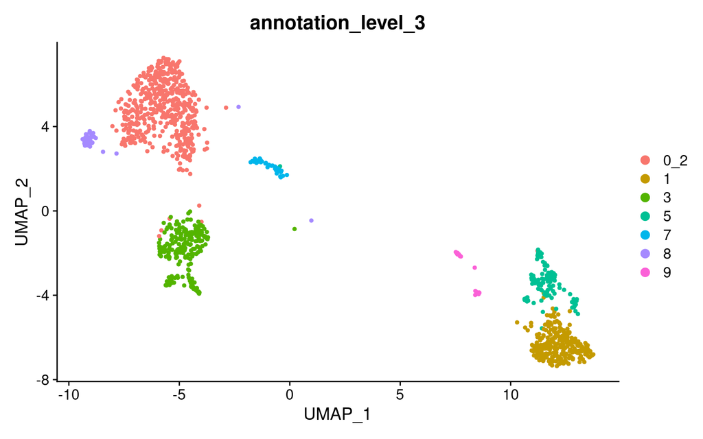

```r
seurat$annotation_level_3[seurat$annotation_level_3 %in% c("0", "2")] <- "0_2"
Idents(seurat) <- "annotation_level_3"
DimPlot(seurat, group.by = "annotation_level_3")
```

### 5.0.2 Cluster 3

```r
seurat <- FindNeighbors(seurat, reduction = "harmony", dims = 1:15)
seurat <- FindSubCluster(seurat, "3", "RNA_snn", "sub3", resolution = 0.3)
```

```
## Modularity Optimizer version 1.3.0 by Ludo Waltman and Nees Jan van Eck
##
## Number of nodes: 223
## Number of edges: 6836
##
## Running Louvain algorithm...
## Maximum modularity in 10 random starts: 0.7225
## Number of communities: 3
## Elapsed time: 0 seconds
```

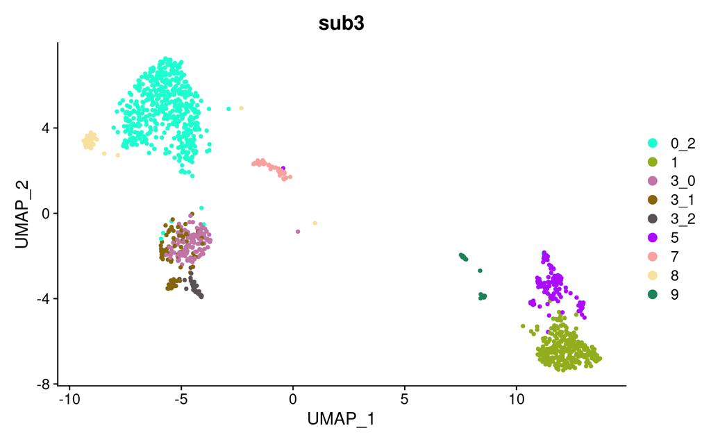

```r
DimPlot(seurat, group.by = "sub3", cols = color_palette)
```

```r
Idents(seurat) <- "sub3"
markers_sub3 <- FindMarkers(seurat, ident.1 = "3_1", ident.2 = c("3_0", "3_2"), only.pos = FALSE)
markers_sub3 <- markers_sub3 %>%
  rownames_to_column("gene") %>%
  arrange(desc(avg_log2FC))
DT::datatable(markers_sub3)
```

|  | gene | p_val | avg_log2FC | pct.1 | pct.2 | p_val_adj |
| --- | --- | --- | --- | --- | --- | --- |
| 1 | XIST | 0.859186528875003 | 1.06833310374825 | 0.117 | 0.137 | 1 |
| 2 | NOVA1 | 0.0703382163382904 | 1.05579541943569 | 0.234 | 0.151 | 1 |
| 3 | C1S | 0.0236274481922773 | 0.936384959816345 | 0.364 | 0.295 | 1 |
| 4 | ALPK2 | 0.781214123864525 | 0.910449469579167 | 0.156 | 0.164 | 1 |
| 5 | NFIA | 0.796120344003028 | 0.871508848542982 | 0.26 | 0.315 | 1 |
| 6 | MACF1 | 0.0222144668973057 | 0.865873765836856 | 0.351 | 0.274 | 1 |
| 7 | SLFN5 | 0.237366756927093 | 0.863242684098902 | 0.273 | 0.253 | 1 |
| 8 | PRRX1 | 0.254296464167184 | 0.862382050866083 | 0.299 | 0.301 | 1 |
| 9 | NEAT1 | 0.79279532959763 | 0.861265322437151 | 0.208 | 0.219 | 1 |
| 10 | PMEPA1 | 0.279260422599259 | 0.840007093627994 | 0.182 | 0.151 | 1 |

[output cut: 1442 more lines]

```r
markers_sub3 <- find_markers_subclusters(seurat, "sub3", "^3_")
DT::datatable(markers_sub3$`3_0`)
```

|  | gene | p_val | avg_log2FC | pct.1 | pct.2 | p_val_adj |
| --- | --- | --- | --- | --- | --- | --- |
| 1 | FABP5 | 3.78822252477442e-10 | 0.971532516065139 | 0.829 | 0.406 | 1.41596181531018e-05 |
| 2 | RPS4Y1 | 2.0730885243245e-05 | 0.864362218248814 | 0.504 | 0.217 | 0.77487902862201 |
| 3 | HSPE1 | 3.19878567795066e-09 | 0.858200370842291 | 0.829 | 0.406 | 0.00011956421107044 |
| 4 | RPL22L1 | 7.72270122665923e-07 | 0.852625064537433 | 0.795 | 0.481 | 0.0288659126450069 |
| 5 | CCT8 | 1.87415162732659e-09 | 0.824364456319707 | 0.761 | 0.321 | 7.00520395262132e-05 |
| 6 | DDX21 | 7.84485992737034e-06 | 0.811562634950244 | 0.556 | 0.245 | 0.293225174365248 |
| 7 | HIST1H1A | 6.98300447627094e-06 | 0.779407069527986 | 0.256 | 0.038 | 0.261010741314055 |
| 8 | NDUFAF8 | 1.09198407552826e-07 | 0.769202227456337 | 0.556 | 0.198 | 0.00408161807750953 |
| 9 | HMGA1 | 6.96863532594389e-08 | 0.750844876103426 | 0.897 | 0.491 | 0.00260473651213131 |
| 10 | DANCR | 6.72690261764874e-08 | 0.746057841783485 | 0.624 | 0.226 | 0.00251438166042475 |

[output cut: 59 more lines]

```r
DT::datatable(markers_sub3$`3_1`)
```

|  | gene | p_val | avg_log2FC | pct.1 | pct.2 | p_val_adj |
| --- | --- | --- | --- | --- | --- | --- |
| 1 | XIST | 0.859186528875003 | 1.06833310374825 | 0.117 | 0.137 | 1 |
| 2 | NOVA1 | 0.0703382163382904 | 1.05579541943569 | 0.234 | 0.151 | 1 |
| 3 | C1S | 0.0236274481922773 | 0.936384959816345 | 0.364 | 0.295 | 1 |
| 4 | ALPK2 | 0.781214123864525 | 0.910449469579167 | 0.156 | 0.164 | 1 |
| 5 | NFIA | 0.796120344003028 | 0.871508848542982 | 0.26 | 0.315 | 1 |
| 6 | MACF1 | 0.0222144668973057 | 0.865873765836856 | 0.351 | 0.274 | 1 |
| 7 | SLFN5 | 0.237366756927093 | 0.863242684098902 | 0.273 | 0.253 | 1 |
| 8 | PRRX1 | 0.254296464167184 | 0.862382050866083 | 0.299 | 0.301 | 1 |
| 9 | NEAT1 | 0.79279532959763 | 0.861265322437151 | 0.208 | 0.219 | 1 |
| 10 | PMEPA1 | 0.279260422599259 | 0.840007093627994 | 0.182 | 0.151 | 1 |

[output cut: 134 more lines]

Since it is hard to separate, I propose to keep this cluster and label it “proliferative FDC/doublets”. However, to gain more resolution in the annotation of the other clusters, we can subset it (similar to CD4 T cells):

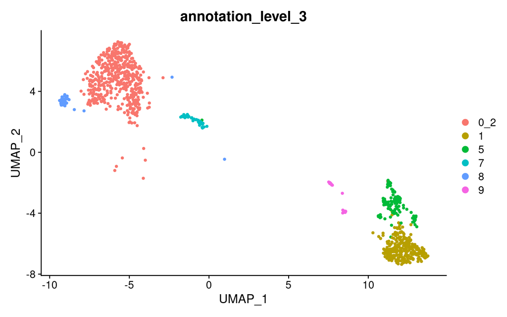

```r
proliferative_doublets <- subset(seurat, annotation_level_3 == "3")
seurat <- subset(seurat, annotation_level_3 != "3")
DimPlot(seurat, group.by = "annotation_level_3")
```

# 6 Get cluster 9 (epithelial)

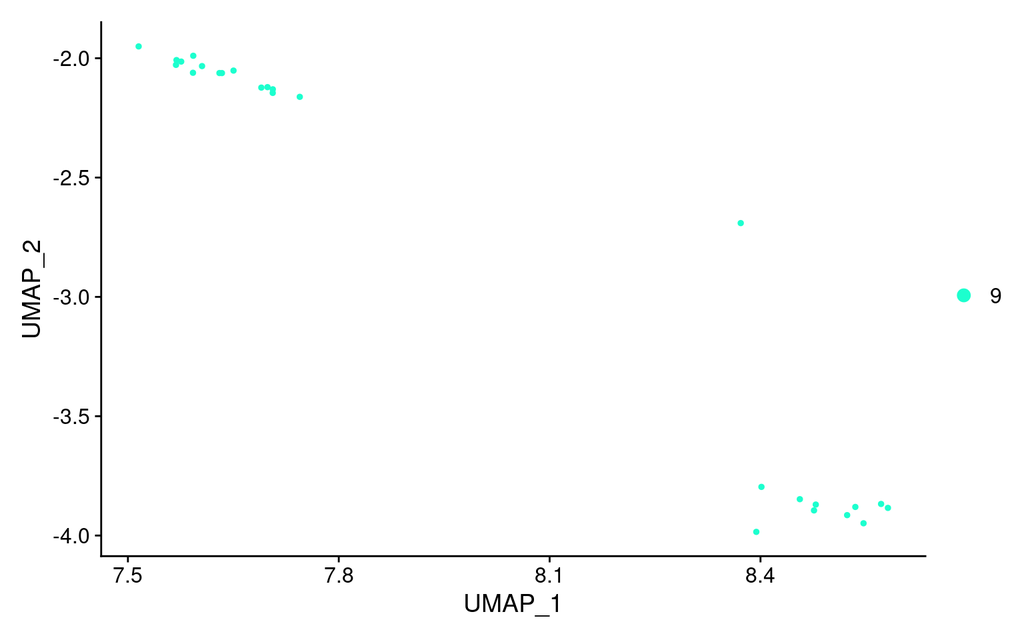

```r
epithelial <- subset(seurat, annotation_level_3 == "9")
seurat <- subset(seurat, annotation_level_3 != "9")
DimPlot(epithelial, cols = color_palette)
```

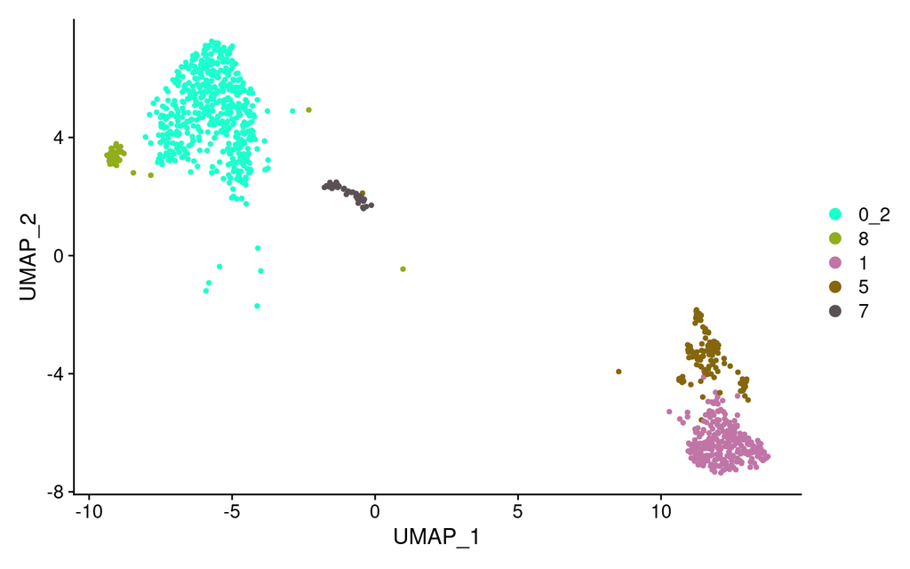

```r
Idents(seurat) <- "annotation_level_3"
DimPlot(seurat, cols = color_palette)
```

# 7 Reintegrate

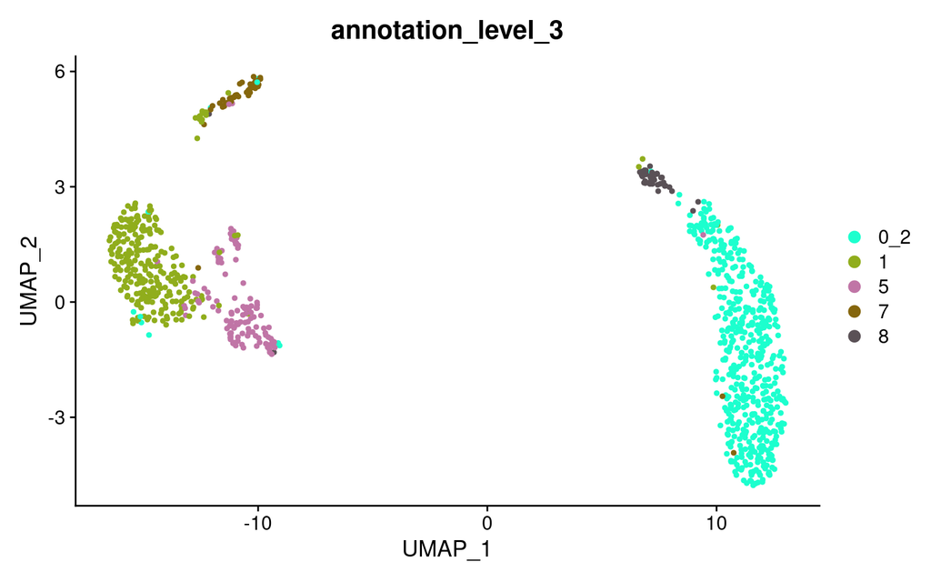

```r
seurat <- seurat %>%
  FindVariableFeatures() %>%
  ScaleData() %>%
  RunPCA() %>%
  RunHarmony(group.by.vars = "donor_id", reduction = "pca", dims = 1:20) %>%
  RunUMAP(reduction = "harmony", dims = 1:20, n.neighbors = 20)
DimPlot(seurat, group.by = "annotation_level_3", cols = color_palette)
```

# 8 Recluster

```r
seurat <- FindNeighbors(
  seurat,
  dims = 1:20,
  reduction = "harmony",
  k.param = 20
)
seurat <- FindClusters(seurat, resolution = 0.7)
```

```
## Modularity Optimizer version 1.3.0 by Ludo Waltman and Nees Jan van Eck
##
## Number of nodes: 962
## Number of edges: 44753
##
## Running Louvain algorithm...
## Maximum modularity in 10 random starts: 0.7657
## Number of communities: 7
## Elapsed time: 0 seconds
```

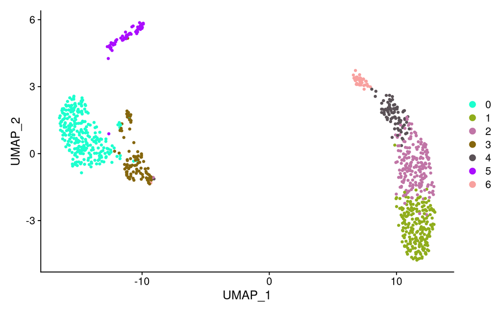

```r
DimPlot(seurat, cols = color_palette)
```

Let us join clusters 1, 2 and 4 in a single cluster; and split cluster 3 in 3:

```r
# Merge
seurat$annotation_level_4 <- as.character(seurat$seurat_clusters)
seurat$annotation_level_4[seurat$annotation_level_4 %in% c("1", "2", "4")] <- "1"


# Split
Idents(seurat) <- "annotation_level_4"
seurat <- FindSubCluster(seurat, "3", "RNA_snn", "sub3_level_4", resolution = 0.7)
```

```
## Modularity Optimizer version 1.3.0 by Ludo Waltman and Nees Jan van Eck
##
## Number of nodes: 97
## Number of edges: 2471
##
## Running Louvain algorithm...
## Maximum modularity in 10 random starts: 0.4757
## Number of communities: 3
## Elapsed time: 0 seconds
```

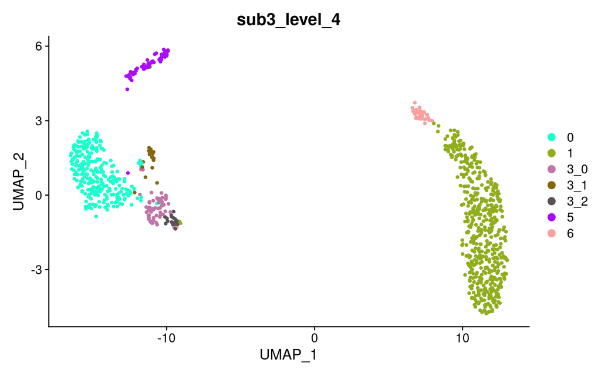

```r
DimPlot(seurat, group.by = "sub3_level_4", cols = color_palette)
```

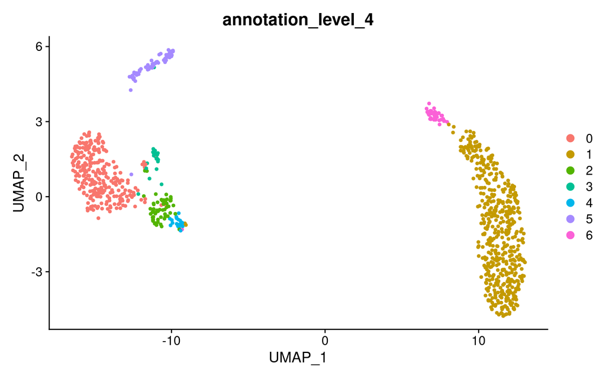

```r
# Rename
seurat$annotation_level_4 <- case_when(
  seurat$sub3_level_4 == "0" ~ "0",
  seurat$sub3_level_4 == "1" ~ "1",
  seurat$sub3_level_4 == "3_0" ~ "2",
  seurat$sub3_level_4 == "3_1" ~ "3",
  seurat$sub3_level_4 == "3_2" ~ "4",
  seurat$sub3_level_4 == "5" ~ "5",
  seurat$sub3_level_4 == "6" ~ "6"
)
Idents(seurat) <- "annotation_level_4"
DimPlot(seurat, group.by = "annotation_level_4")
```

## 8.1 Markers

```r
markers_new <- FindAllMarkers(seurat, only.pos = TRUE, logfc.threshold = 0.75)
```

# 9 Generate outputs

```r
shiny_output <- seurat2shiny(seurat, assay = "RNA", reduction = "umap", slot = "data")
```

# 10 Save

```r
# Save Seurat objects
saveRDS(seurat, path_to_save_fdc)
saveRDS(epithelial, path_to_save_epithelial)
saveRDS(proliferative_doublets, path_to_save_proliferative)
```

```r
# Save shiny
saveRDS(
  shiny_output$metadata,
  "~/Desktop/CNAG/mnt_clust/tonsil_atlas/current/scRNA-seq/results/R_objects/level_4/FDC/FDC_metadata_to_shiny_app_level_4.rds"
)
saveRDS(shiny_output$expression, "~/Desktop/CNAG/mnt_clust/tonsil_atlas/current/scRNA-seq/results/R_objects/level_4/FDC/FDC_expression_to_shiny_app_level_4.rds")
```

```r
# Markers
markers_new_list <- purrr::map(unique(markers_new$cluster), function(x) {
  df <- markers_new[markers_new$cluster == x, ]
  df
})
names(markers_new_list) <- unique(markers_new$cluster)
markers_new_list <- markers_new_list[as.character(0:6)]
openxlsx::write.xlsx(x = markers_new_list, "~/Desktop/CNAG/mnt_clust/tonsil_atlas/current/scRNA-seq/3-clustering/4-level_4/FDC/tmp/markers_FDC_level_4.xlsx")
```

```r
# Save
ggsave(
  filename = "~/Desktop/CNAG/mnt_clust/tonsil_atlas/current/scRNA-seq/3-clustering/4-level_4/FDC/tmp/FDC_umap_level_4.png",
  plot = DimPlot(seurat, cols = color_palette),
  width = 14,
  height = 12,
  units = "cm"
)
```